# Homogeneus habitat results

Iosu

3/8/2020

# Objective

**Test** the performance of different **species interaction models under a PERFECT scenario** (no missing covariate effects)

- Can we use model selection scores to assess the type of interaction ?

# Simulation

Our simulation iteratively adds new specimens into the study area given the proximity to other specimens of the same species (spat autoc) and the interaction with the amount of animals of the other species in that site:

- The distributiuon of the species. Sort of a dispersal effect that helps spatial correlation
- The abundance of the other species and the particular interaction with it

We are testing:

- **Homogeneous habitat**: *the aim is to test whether we can withdraw informative interaction parameters through joint modelling*. There is no environmental heterogeneity, i.e. the drivers of the distributions are only the interaction and the spatial autocorrelation “dispersal effect”

# Model selection scores

- **WAIC**: goodness of fit
- **LCPO**: leave-one-out cross-validation score
- **PIT_overlap**: PIT values in a good model should follow a unifrom distribution. Here we check the similarity/overlap of the observed PIT values with a uniform distribution

Cross validation 5 times (20 percent of data out each time)

- **MAE**: mean absolute error of remaining 20% of data
- **CRPS**: checks how well the posterio distribution contains the actual observed value. Perfrmed over the remaining 20% of the data.

# Fitted models

Every joint model is scaled in Sp2’s predictor.

*W* refers to a geostatistical field

## Indep

Two independent models

$\begin{align} \eta1 & = Interc_{1} + W_1 \\ \eta2 & = Interc_{2} + W_2 \\ \end{align}$

## Traditional interaction

Two independent models

$\begin{align} \eta1 & = Intercept_{1} + W_1 + \beta_{1}*obs_1 \\ \eta2 & = Intercept_{2} + W_2 + \beta_{2}*obs_2\\ \end{align}$

## Model 0

A joint spatial model

$\begin{align} \eta1 & = Intercept_{1} + \alpha_1 * W \\ \eta2 & = Intercept_{2} + \alpha_2 * W \\ \end{align}$

## Model 1

A joint spatial model + extra spatial model in Sp1

$\begin{align} \eta1 & = Intercept_{1} + \alpha_1 * W + W_1 \\ \eta2 & = Intercept_{2} + \alpha_2 * W \\ \end{align}$

## Model 2

A joint spatial model + extra spatial model in Sp2

$\begin{align} \eta1 & = Intercept_{1} + \alpha_1 * W \\ \eta2 & = Intercept_{2} + \alpha_2 * W + W_2 \\ \end{align}$

# Homogeneus habitat results

## — and —

**Observations:**

### Simulated model model

- Sp2 NO effect on Sp1
- Sp1 NO effect on Sp2

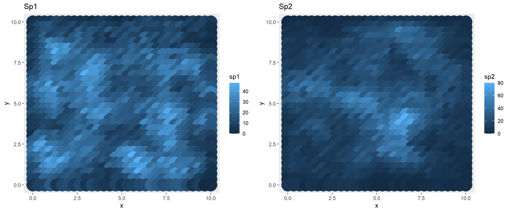

### Scaling parameter

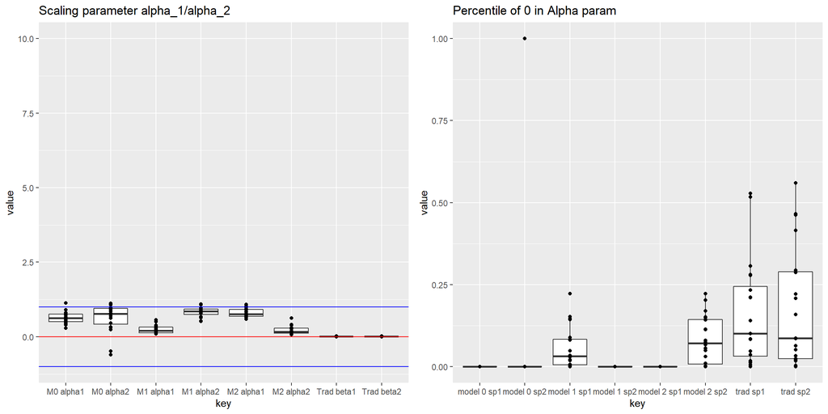

### Scaled model selection scores

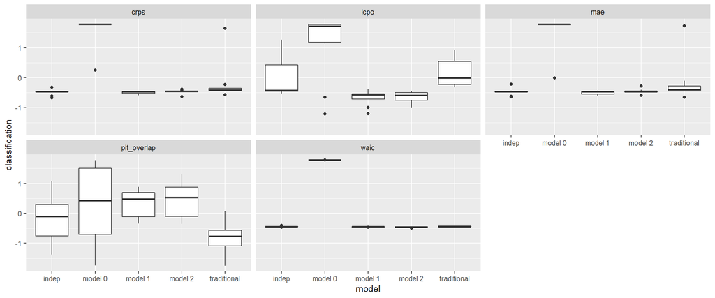

### Model selection scores

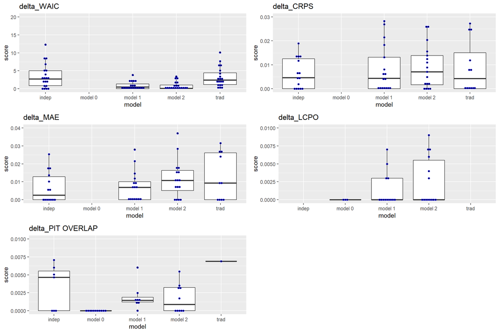

### Ranked model selection scores

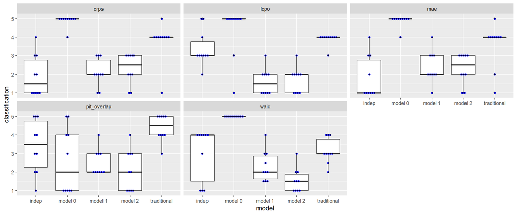

## — and +0.25

**Observations:**

### Simulated model model

- Sp2 NO effect on Sp1
- Sp1 +0.25 effect on Sp2

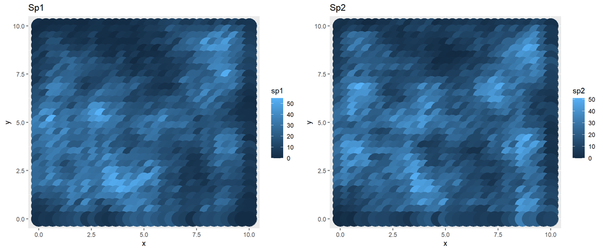

### Scaling parameter

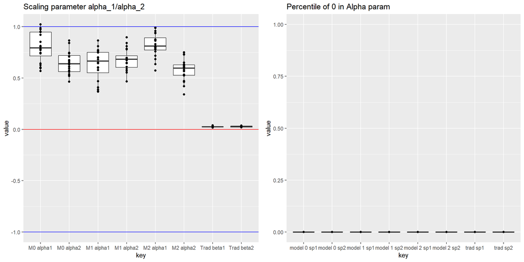

### Scaled model selection scores

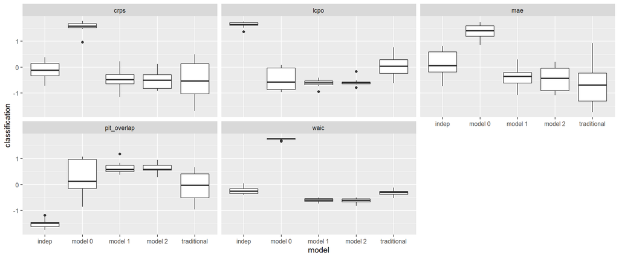

### Model selection scores

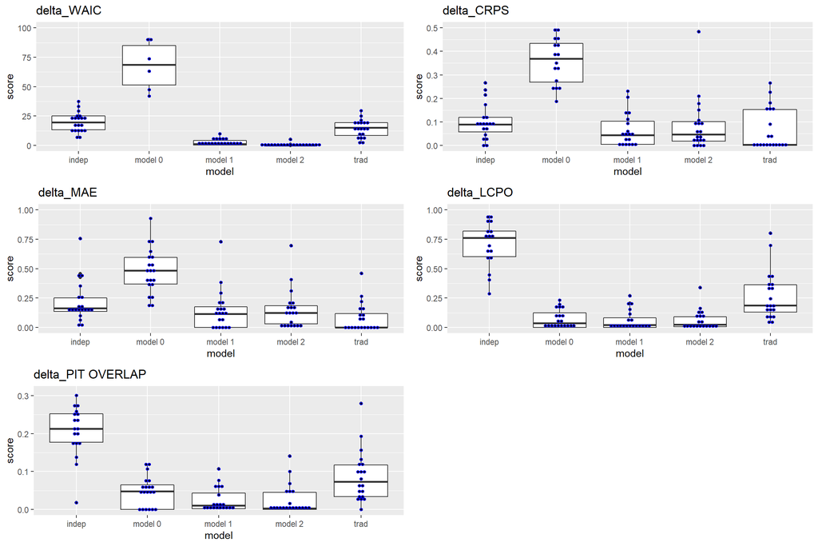

### Ranked model selection scores

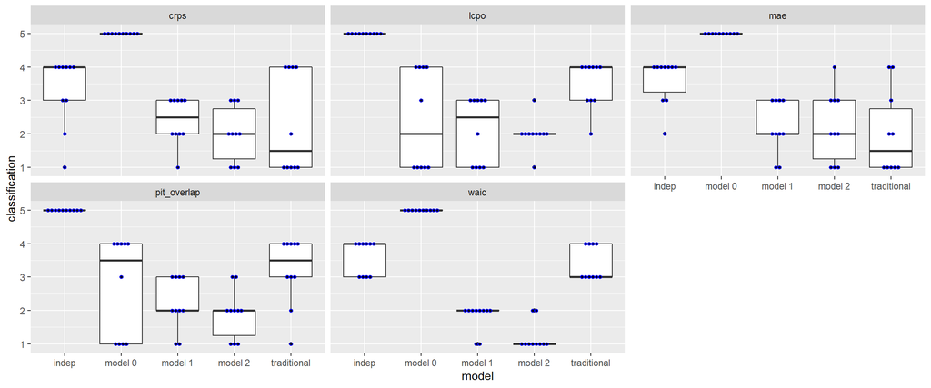

## — and -0.25

**Observations:**

### Simulated model model

- Sp2 NO effect on Sp1
- Sp1 -0.25 effect on Sp2

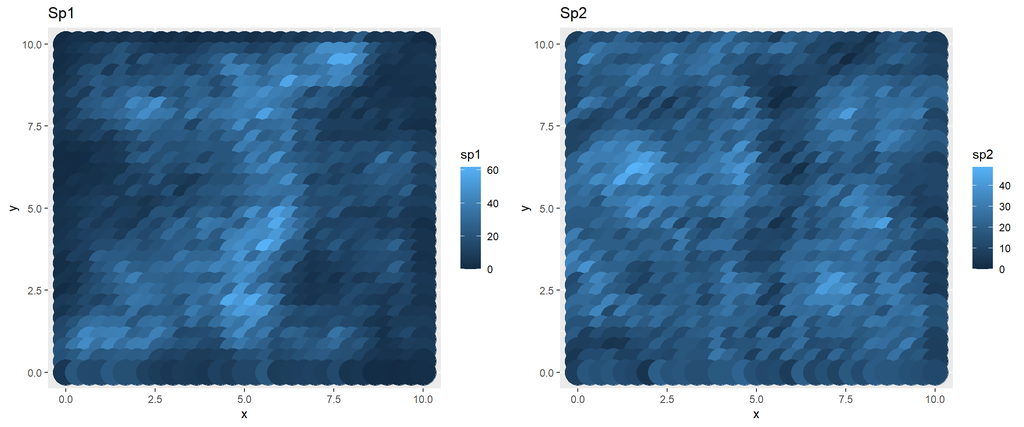

### Scaling parameter

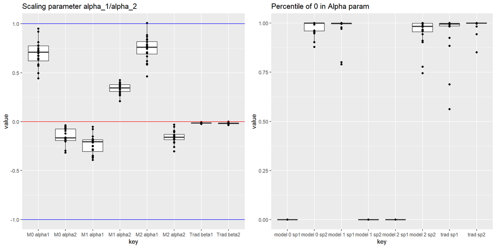

### Scaled model selection scores

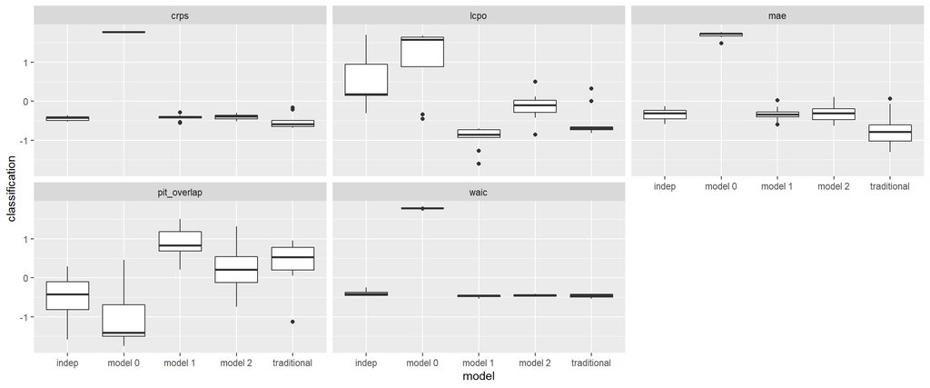

### Model selection scores

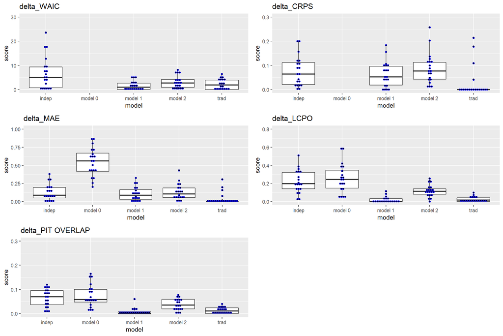

### Ranked model selection scores

[output not shown]

[output cut: 486 more lines]

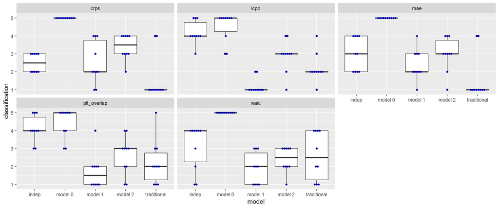

## -0.25 and +0.25

**Observations:**

### Simulated model model

- Sp2 -0.25 effect on Sp1
- Sp1 +0.25 effect on Sp2

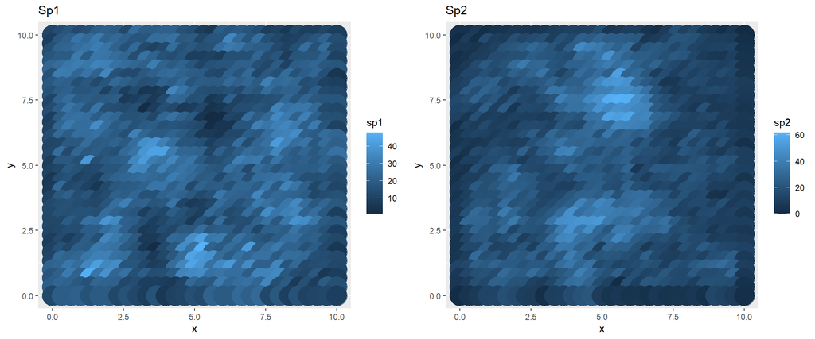

### Scaling parameter

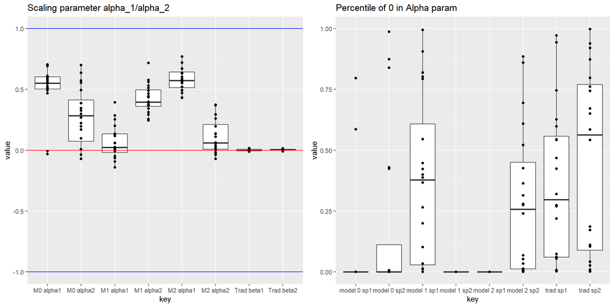

### Scaled model selection scores

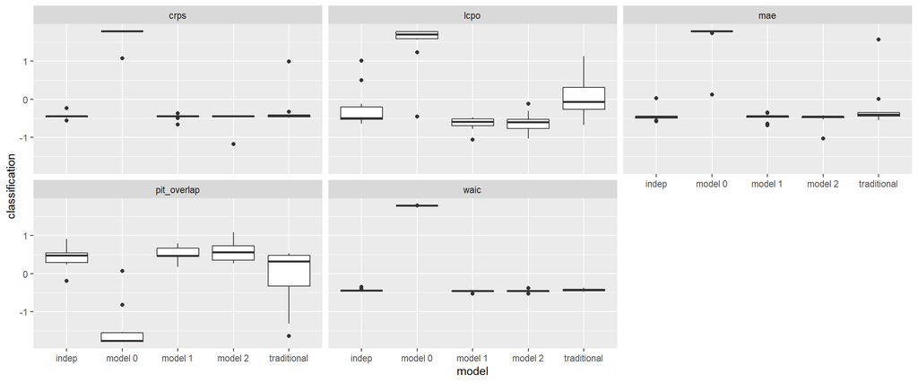

### Model selection scores

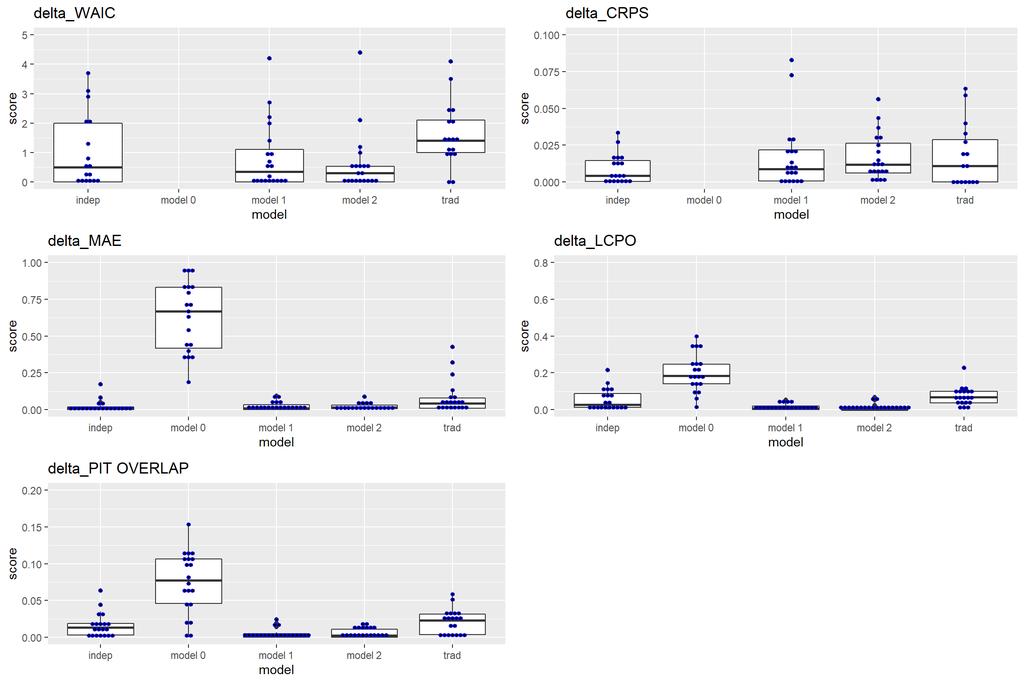

### Ranked model selection scores

[output not shown]

[output cut: 486 more lines]

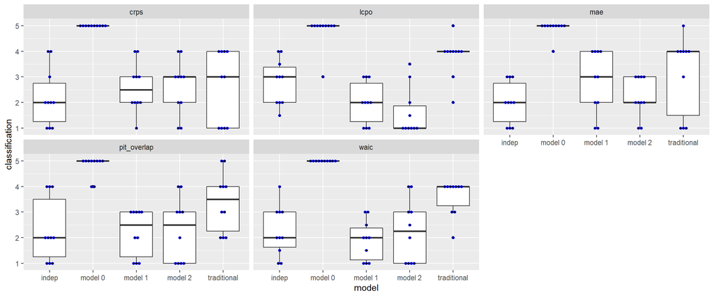

## +0.25 and +0.25

**Observations:**

### Simulated model model

- Sp2 +0.25 effect on Sp1
- Sp1 +0.25 effect on Sp2

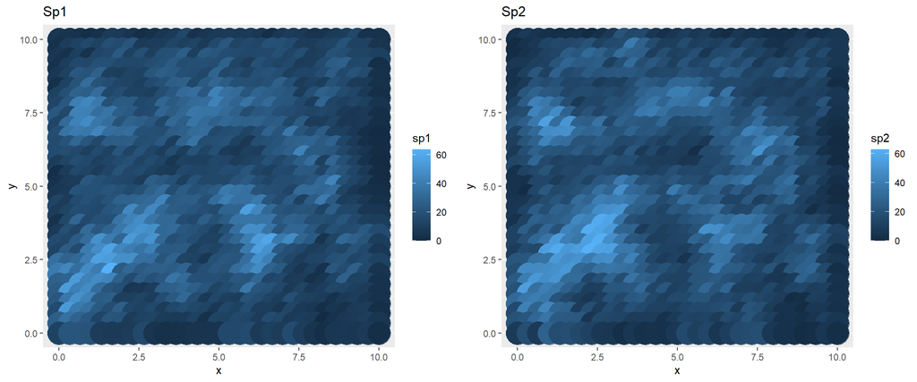

### Scaling parameter

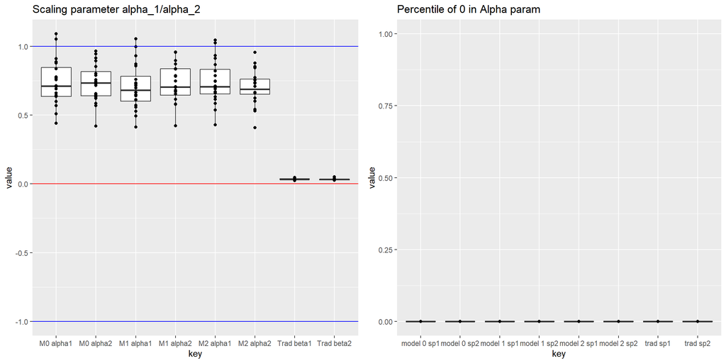

### Scaled model selection scores

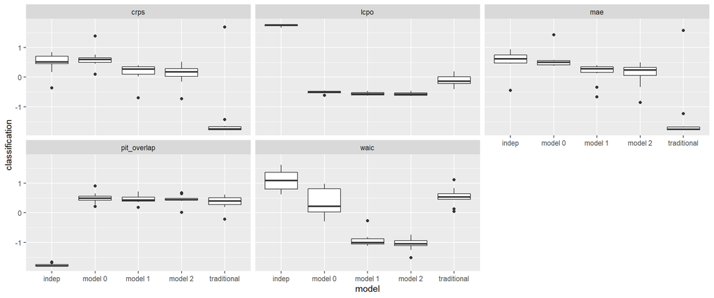

### Model selection scores

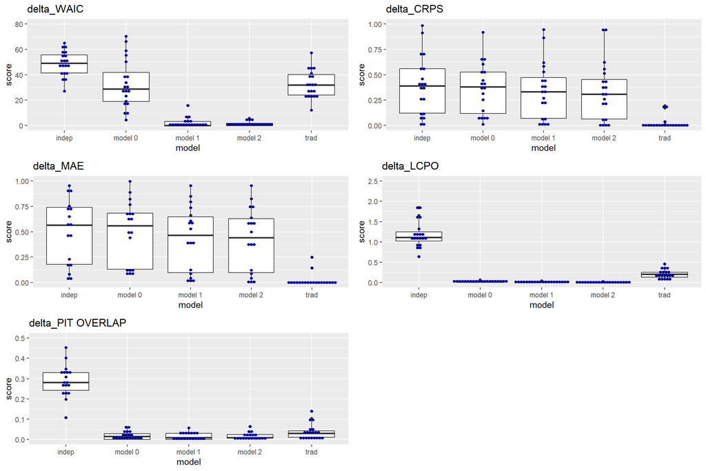

### Ranked model selection scores

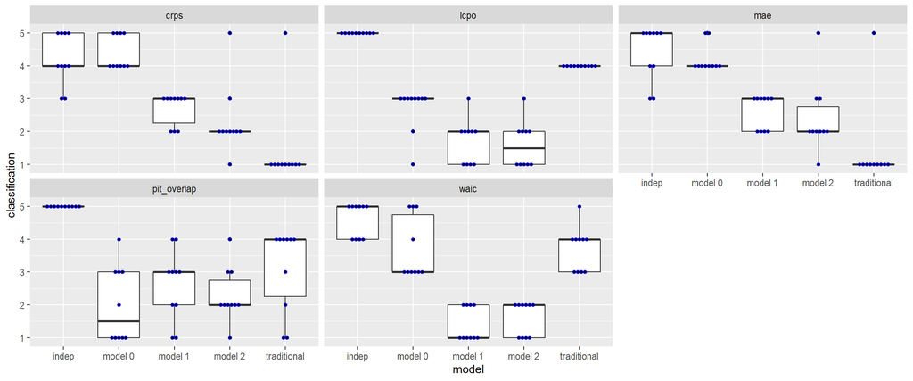

## -0.25 and -0.25

**Obsercations:**

### Simulated model model

- Sp2 -0.25 effect on Sp1
- Sp1 -0.25 effect on Sp2

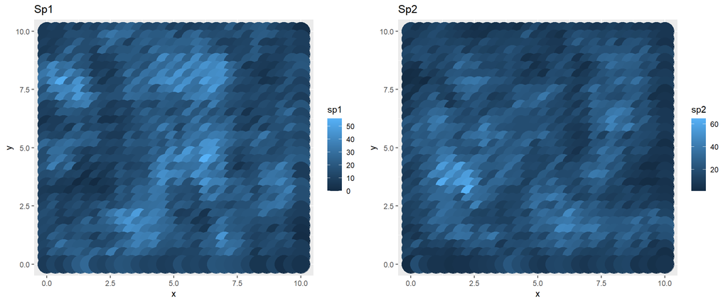

### Scaling parameter

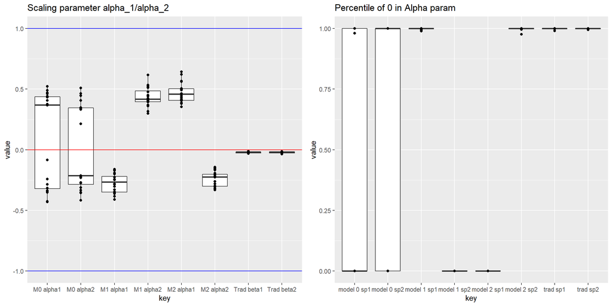

### Scaled model selection scores

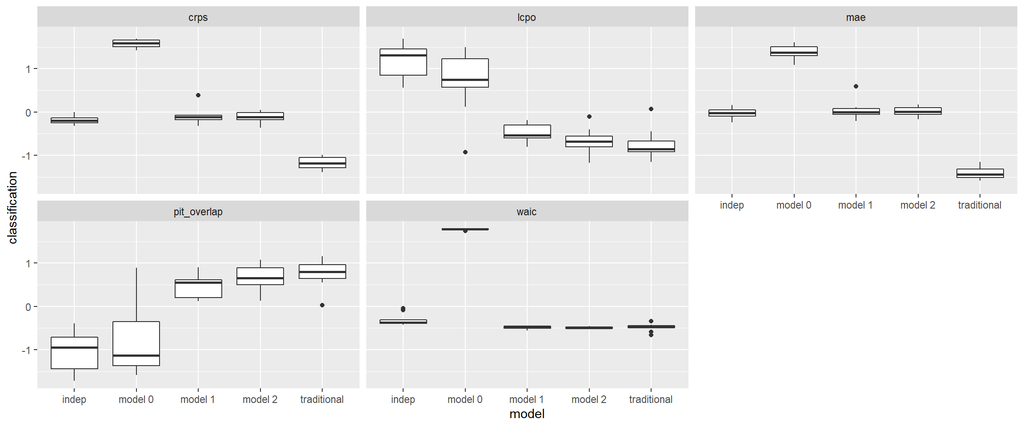

### Model selection scores

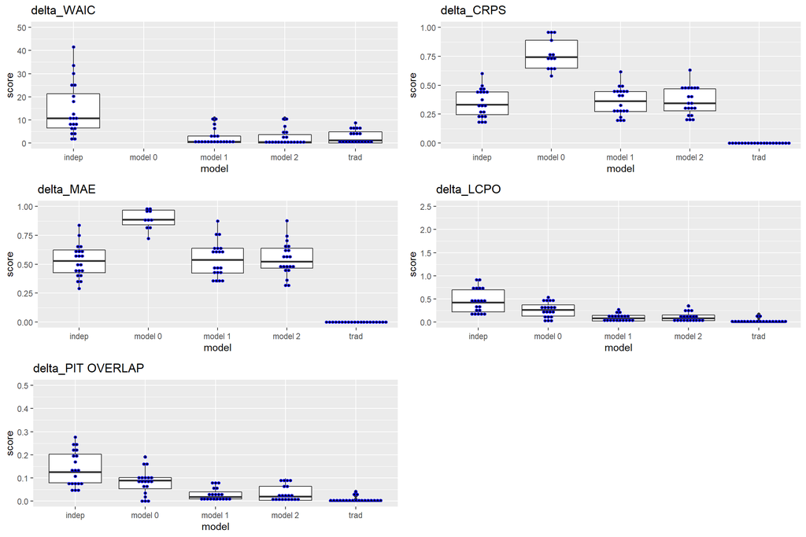

### Ranked model selection scores

[output not shown]

[output cut: 486 more lines]

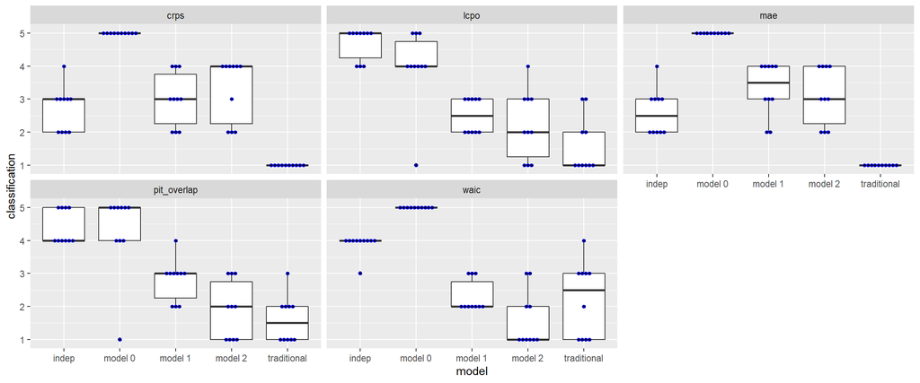